# Introduction

Institut für Organisation und Globale Managementstudien, JKU Linz

## Today's Agenda

- Evidence Based Management
- Data Science
- **Your accomplishments at the end of the seminar**
- Installation of R and RStudio
- Example: Working with R
- Learning R with swirl

## Motivation for this Course

## Evidence Based Management

"… the idea that decisions … should be based on the latest and best knowledge of what actually works" [Pfeffer & Sutton, 2006](https://hbr.org/2006/01/evidence-based-management)

Why is it hard?

- There's too much evidience
- There's not enough good evidence
- The evidence doesn't quite apply
- People are trying to mislead you
- You are trying to mislead you
- The side effects outweigh the cure
- Stories are more persuasive anyway

## Evidence Based Management

Typical research process in EBMgt is similar to academic research.

[Lehner & Farthofer, 2012](http://www.lindeverlag.at/titel-56-56/evidenzbasiertes_management-4741/)

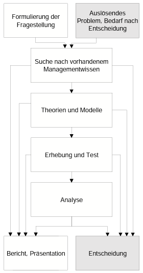

## NASA: Evidience Based Customer Service

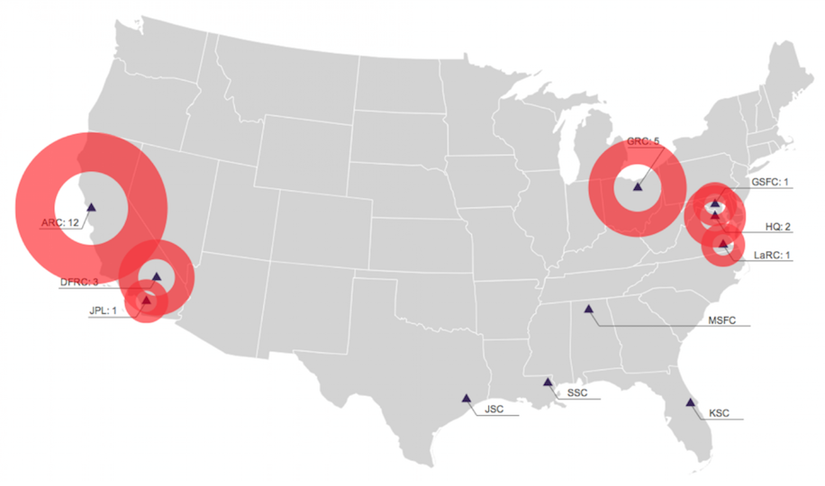

## Big Data

In 2010, the [Economist](http://www.economist.com/node/15579717) published the article **"The data deluge"**.

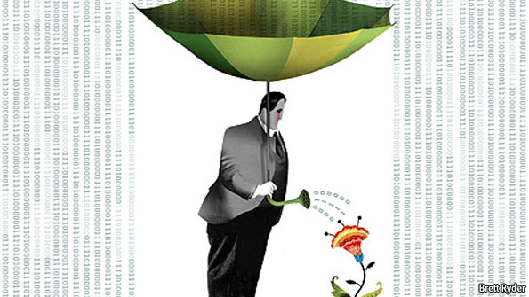

"Businesses, governments and society are only starting to tap its vast potential."

[figure not shown]

## What is Data Science?

[Drew Conway: Data Science Through the Lens of Social Science](http://www.drewconway.com/zia/?p=2378)

## Why R? The Big Picture

- R is becoming the “lingua franca” of data science
- Companies are using R (Google, Facebook, Microsoft)
- R is [popular in academia](http://www.nature.com/news/programming-tools-adventures-with-r-1.16609)

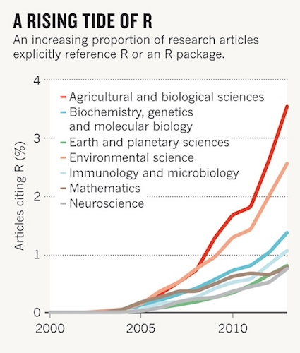

[Sharp Sight Labs, 2015](http://www.r-bloggers.com/why-you-should-learn-r-first-for-data-science/)

## IEEE 2015 Ranking of Programming Languages

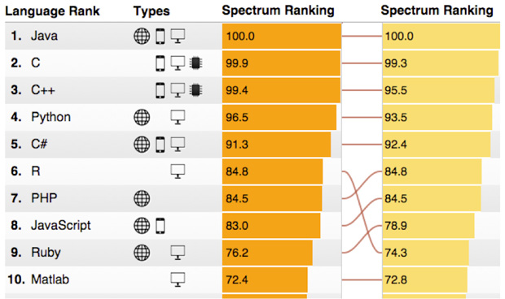

[IEEE Spectrum](http://spectrum.ieee.org/computing/software/the-2015-top-ten-programming-languages)

- It is free
- It has a comprehensive set of packages
- Data access
- Data cleaning
- Analysis
- Data reporting
- It has one of the best development environments - Rstudio http://www.rstudio.com/
- It has an amazing ecosystem of developers
- Packages (i.e. extensions) are easy to install and "play nicely together"

## Acknowledgements

## Acknowledgements

This class and many slides were inspired by:

**Brian Caffo, Jeff Leek, and Roger Peng**  
Department of Biostatistics  
Johns Hopkins Bloomberg School of Public Health

and the

[Data Science Specialization Program](https://www.coursera.org/specialization/jhudatascience/1?utm_medium=courseDescripTop)